# Learn to Code:

## Zero to Sixty Data Analysis

### Website: goo.gl/i5O6qR

Or wackywendell.github.io/learntocode

[figure not shown]

## Goals

- Learn the basics of programming
- Learn to import, manipulate, and plot data

### Why Python?

- Easy to learn and use
- Relatively simple
- Good for data analysis and plotting
- Good for machine learning, web development, scripting, text parsing, and many things.

## Why Python?

[figure not shown]

Python is a full-featured language for generic programming, and data analysis, and it can also make *beautiful* plots. I made this plot last week. It took about 20-40 lines of code!

## Installing Python

[Install Anaconda](http://continuum.io/downloads), and **get the Python 3.4 version!**

#### http://continuum.io/downloads

#### Let's install it now.

- Windows or OS X: use the link above.
- Linux: Use the package manager, and/or ask for help.

## Let's try it!

1. Open the Terminal
2. Type `ipython notebook`
3. Press `Enter`
4. A window should open in your browser!
   - If it does not, look for text like  
     `The IPython Notebook is running at: http://localhost:8888/`
   - Open that link
   - Try `Ctrl-Click` if necessary.
5. At the top right, click `New`, and under `Notebooks` click `Python 3`.

### Let's do some plotting!

```python
%pylab inline
```

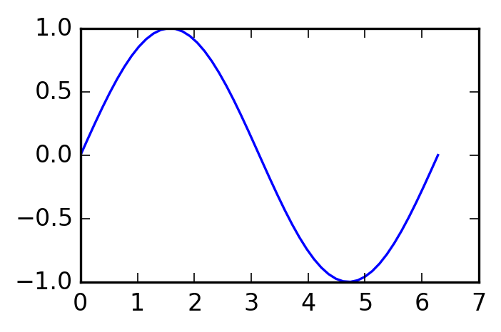

```python
xs = np.linspace(0, np.pi*2)
ys = np.sin(xs)
plot(xs, ys)
```

### Debugging

```
plot([1,2,3,4,5,6,7,8,9,10], [1,4,8,2,3,5,8,9,3,6,7])
```

```
---------------------------------------------------------------------------
ValueError                                Traceback (most recent call last)
<ipython-input-18-ec77aff7bf8c> in <module>()
----> 1 plot([1,2,3,4,5,6,7,8,9,10], [1,4,8,2,3,5,8,9,3,6,7])

/usr/lib/python3.5/site-packages/matplotlib/pyplot.py in plot(*args, **kwargs)
   3097         ax.hold(hold)
   3098     try:
-> 3099         ret = ax.plot(*args, **kwargs)
   3100         draw_if_interactive()
   3101     finally:

[…]

/usr/lib/python3.5/site-packages/matplotlib/axes/_base.py in _xy_from_xy(self, x, y)
    221         y = np.atleast_1d(y)
    222         if x.shape[0] != y.shape[0]:
--> 223             raise ValueError("x and y must have same first dimension")
    224         if x.ndim > 2 or y.ndim > 2:
    225             raise ValueError("x and y can be no greater than 2-D")

ValueError: x and y must have same first dimension
```

## Debugging

### Writing code means fixing errors. Lots of errors.

- Don't be afraid to try new things and raise new errors.
- We'll get lots of practice with debugging in this series!

## Exiting IPython Notebook

1. Go back to the terminal
   - You'll see a line like `[I 13:38:34.691 NotebookApp] Kernel started: 26190742-9d29-420f-9f0f-5c8aae026a62`
2. Press `Ctrl-C`
   - It will ask you `Shutdown this notebook server (y/[n])?`
3. Press `y` then `Enter`
4. Close any windows in your browser

## Getting back to the IPython Notebook

1. Open the Terminal
2. Type `ipython notebook`
3. Press `Enter`
4. A window should open in your browser!
   - If it does not, look for text like  
     `The IPython Notebook is running at: http://localhost:8888/`
   - Open that link
   - Try `Ctrl-Click` if necessary.
5. Look for the notebook from before, probably named `Untitled.ipynb`, and click on it

## Thanks for coming!

- Please fill out your feedback cards, and leave them by the door!
- Come on Thursday for our first Open Session!
- Try the practice problems, available on the website!